# 差の差法推定 Difference-in-Differences

TWFE推定

最終更新: 2023-11-20

ここではTwo-Way Fixed Effect（TWFE）推定量が適切に差の差法推定量となるようなデータ生成過程と、そうでないようなデータ生成過程における挙動を`bacondecomp`パッケージを用いて示し、行うべき修正推定量を示す。`AppliedEconometrics`から呼び出している関数は`R/functions_did.R`に定義されている。

はじめに、個体数`N`と期間`T`を設定する。

```r
N <- 500
T0 <- 4
T1 <- 6
T <- T0 + T1
```

## 0.1 データの生成

統制下の潜在結果関数を以下のように生成する：

$$\begin{align*}
y^*_{t}(0) =& a_i + b_t + e_{it}
\end{align*}$$

ただし、 - 固定効果`a_i`: 2020年度大卒女性新卒者初任給を対数正規分布近似したもの。 - 時間効果`b_t`: 線形トレンド - 撹乱項`e_it`: iidの正規分布誤差 とする。

一方で、処置群ダミー`g_i`は固定効果`a_i`について線形のロジット

$$\begin{align*}
P(g_i|a_i) =& \frac{\exp(\alpha_0 + \alpha_1 a_i)}{1 + \exp(\alpha_0
+ \alpha_1 a_i)}
\end{align*}$$

にて与える。処置`d_it`は処置期間`t \geq T0 + 1`に一斉に与えられるものとし、処置下の潜在結果関数は

$$\begin{align*}
y^*_{t}(1) =& y^*_t(0) + d_{it} \tau_i \tau_t
\end{align*}$$

で与えられ、`\tau_i \sim N(0.05,0.2)`と`\tau_t ~ U[0.9,1.1]`とする。

```r
set.seed(1)
df_base <-
  AppliedEconometrics::generate_df_no_covariates(
    N = N,
    T = T,
    T0 = T0
  )
```

# 1 同時割り当てにおける推定

このとき、ノンパラメトリックな差の差推定は以下のように平均差で与えられる。

```r
# 処置群割合
print(mean(df_base$g_i))
```

```
## [1] 0.396
```

```r
# 事後期間
post <-
  mean(df_base$y_it[
    (df_base$time > T0) &
      (df_base$g_i == 1)
    ]) -
  mean(df_base$y_it[
    (df_base$time > T0) &
      (df_base$g_i == 0)
    ])

# 事前期間
pre <-
  mean(df_base$y_it[
    (df_base$time <= T0) &
      (df_base$g_i == 1)
    ]) -
  mean(df_base$y_it[
    (df_base$time <= T0) &
      (df_base$g_i == 0)
    ])

# 実際の処置者平均処置効果
print(
  data.frame(
    did = c(pre,post,post - pre),
    true = c(NA,NA,mean(
      df_base$tau_it[
        (df_base$time > T0) & (df_base$g_i == 1)]))
  ))
```

```
##          did       true
## 1 0.05041024         NA
## 2 0.08254005         NA
## 3 0.03212981 0.03262681
```

さらに、TWFE推定量が平均差推定と一致する。

```r
lsdv <- plm::plm(
  formula = y_it ~ d_it,
  data = df_base,
  index = c("id","time"),
  effect = "twoways")
clubSandwich::coef_test(lsdv, vcov = "CR1", cluster = "id", test = "naive-t")
```

|  | Coef | beta | SE | tstat | df_t | p_t |
| --- | --- | --- | --- | --- | --- | --- |
| d_it | d_it | 0.03212981 | 0.01399183 | 2.296327 | 499 | 0.02207071 |

# 2 複数時点での処置発生

次に、割り当てが複数期に渡って生じるケースを考える。ここで、共変量`x1_i`, `x2_i`を`(0,0), (1,0), (1,1)`の三値を取る二項変数のペアとし、処置群の割り当てが順序付きロジットで行われているとする。すなわち、

$$\begin{align*}
P(g1_i) =& \frac{\exp(\alpha_0 + \alpha^{11} x_{1i} +
\alpha^{12}x_{2i})}{1 + \exp(\alpha_0 + \alpha^{11}x_{1i} +
\alpha^{12}x_{2i})}\\
P(g2_i|x1_i,x2_i) =& \frac{\exp(\alpha_0 + \alpha^{21} x_{1i} +
\alpha^{22}x_{2i})}{1 + \exp(\alpha_0 + \alpha^{21} x_{1i} +
\alpha^{22}x_{2i}))} -
\frac{\exp(\alpha_0 + \alpha^{11} x_{1i} + \alpha^{12}x_{2i}))}{1 +
\exp(\alpha_0 + \alpha^{11} x_{1i} + \alpha^{12}x_{2i})}\\
\ldots & \\
P(g4_i|x1_i,x2_i) =& \frac{\exp(\alpha_0 + \alpha^{41} x_{1i} +
\alpha^{42}x_{2i})}{1 + \exp(\alpha_0 + \alpha^{41} x_{1i} +
\alpha^{42}x_{2i}))} -
\frac{\exp(\alpha_0 + \alpha^{31} x_{1i} + \alpha^{32}x_{2i}))}{1 +
\exp(\alpha_0 + \alpha^{31} x_{1i} + \alpha^{32}x_{2i})}
\end{align*}$$

とする。このとき、

```r
set.seed(1)
df_nocov <- AppliedEconometrics::generate_df_multiperiod(N=N,T=T,T1=T1,T0=T0,diff_trend = FALSE)

# 処置群割合
table_by_group <- data.frame(
  group = c("グループ1",
               "グループ2",
               "グループ3",
               "グループ4",
               "処置群全体"),
  fraction = c(mean(df_nocov$g1_i[1:N]),
               mean(df_nocov$g2_i[1:N]),
               mean(df_nocov$g3_i[1:N]),
               mean(df_nocov$g4_i[1:N]),
               mean(df_nocov$d_it)),
  att = c(mean(df_nocov$tau_it[(df_nocov$time >= T0+1)&(df_nocov$g1_i == 1)]),
          mean(df_nocov$tau_it[(df_nocov$time >= T0+2)&(df_nocov$g2_i == 1)]),
          mean(df_nocov$tau_it[(df_nocov$time >= T0+3)&(df_nocov$g3_i == 1)]),
          mean(df_nocov$tau_it[(df_nocov$time >= T0+4)&(df_nocov$g4_i == 1)]),
          mean(df_nocov$tau_it[df_nocov$d_it == 1]))
)
table_by_group
```

| group | fraction | att |
| --- | --- | --- |
| グループ1 | 0.4840 | 0.15930345 |
| グループ2 | 0.1120 | -0.42986798 |
| グループ3 | 0.0520 | -0.30165983 |
| グループ4 | 0.0300 | -0.14305494 |
| 処置群全体 | 0.3762 | 0.03888117 |

5期に処置を受ける群が割合が大きく、正の効果をもつ一方で、6, 7, 8期に処置を受ける群はそれぞれ割合が小さく、負の効果をもち、全体の処置者平均処置効果は小さい正の効果となる場合を考える。

## 2.1 TWFE推定

このとき、TWFE推定は負の値をとる。

```r
lsdv <- plm::plm(
  formula = y_it ~ d_it,
  data = df_nocov,
  index = c("id","time"),
  effect = "twoways")
clubSandwich::coef_test(lsdv, vcov = "CR1", cluster = "id", test = "naive-t")
```

|  | Coef | beta | SE | tstat | df_t | p_t |
| --- | --- | --- | --- | --- | --- | --- |
| d_it | d_it | -0.01652002 | 0.01677873 | -0.9845814 | 499 | 0.3253069 |

## 2.2 Goodman-baconによる分解

Goodman-baconによる分解を行えば、これはlater-early間の比較、すなわち、先に処置を受けた群を統制群とした差の差推定が全て負の値を生じさせており、結果として全体の処置者平均処置効果推定の符号を反転させるに至っていることがわかる。

```r
result <- bacondecomp::bacon(formula = y_it ~ d_it, data = df_nocov, id_var = "id", time_var = "time")
```

```
##                       type  weight  avg_est
## 1 Earlier vs Later Treated 0.10126  0.09237
## 2 Later vs Earlier Treated 0.09923 -0.32090
## 3     Treated vs Untreated 0.79951  0.00747
```

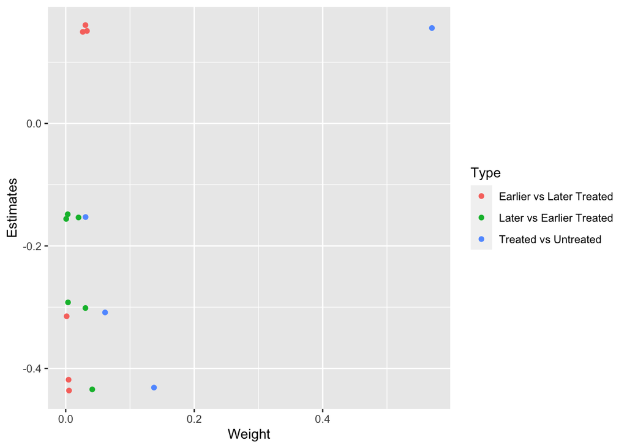

```r
ggplot(result) +
  aes(x = weight, y = estimate, color = factor(type)) +
  labs(x = "Weight", y = "Estimates", color = "Type") +
  geom_point()
```

## 2.3 修正TWFE推定

処置時点での層別を適切に行った回帰を行えば、それぞれ本来の異質なATTが推定できる。

```r
lsdv <- plm::plm(
  formula = y_it ~ d1_it + d2_it + d3_it + d4_it,
  data = df_nocov,
  index = c("id","time"),
  effect = "twoways")
summary(lsdv)
```

```
## Twoways effects Within Model
##
## Call:
## plm::plm(formula = y_it ~ d1_it + d2_it + d3_it + d4_it, data = df_nocov,
##     effect = "twoways", index = c("id", "time"))
##
## Balanced Panel: n = 500, T = 10, N = 5000
##
## Residuals:
##        Min.     1st Qu.      Median     3rd Qu.        Max.
## -0.58665060 -0.03616624  0.00012616  0.03717808  0.52134339
##
## Coefficients:
##         Estimate Std. Error  t-value  Pr(>|t|)
## d1_it  0.1552820  0.0053851  28.8355 < 2.2e-16 ***
## d2_it -0.4311961  0.0082525 -52.2501 < 2.2e-16 ***
## d3_it -0.3061083  0.0116007 -26.3871 < 2.2e-16 ***
## d4_it -0.1503661  0.0159520  -9.4261 < 2.2e-16 ***
## ---
## Signif. codes:  0 '***' 0.001 '**' 0.01 '*' 0.05 '.' 0.1 ' ' 1
##
## Total Sum of Squares:    78.484
## Residual Sum of Squares: 34.323
## R-Squared:      0.56268
## Adj. R-Squared: 0.51278
## F-statistic: 1443.31 on 4 and 4487 DF, p-value: < 2.22e-16
```